# Final Project - Fencing Champions

Samuel Cohen, Alex Schweizer

4/26/20

# Question: Throughout the history of fencing, which countries and which athletes within those countries excelled in the sport of fencing throughout time and earned medals in international tournaments, such as the FIE World Fencing Championships, and the Olympics?

## Setup:

```r
library(xml2)
library(rvest)
library(ggplot2)
library(tidyr)
library(dplyr)
library(DataComputing)
library(tidyverse)
#library(maps)
```

```r
fie <- "https://en.wikipedia.org/wiki/World_Fencing_Championships#World_champions"
fielist <- fie %>%
  read_html() %>%
  html_nodes(css = "table") %>%
  html_table(fill = TRUE)
```

```r
olympics <- "https://en.wikipedia.org/wiki/List_of_Olympic_medalists_in_fencing_(men)"
olympicslist <- olympics %>%
  read_html() %>%
  html_nodes(css = "table") %>%
  html_table(fill = TRUE)
```

### Links to data sources:

FIE Championships: https://en.wikipedia.org/wiki/World_Fencing_Championships#World_champions

Olympics: https://en.wikipedia.org/wiki/List_of_Olympic_medalists_in_fencing_(men)

## About the first data source:

The first dataset contains charts of data from the FIE (Federation Internationale d’Escrime) World Fencing Championships, such as the medal count of each country, the gold medalists of each event for each year and weapon, and the top 10 international fencers in each weapon with the highest medal count. This data would be held within FIE’s website, but apparently there is a Wikipedia page for it, saving me the time. The Wikipedia page was sourced by former fencer, Richard Cohen (not related), and externally linked to the FIE webpage. This data has been recorded since the first ever tournament in 1921, and is kept recorded in the archives for the history books.

Here are some of the tables in the dataset:

```r
medalranks <- fielist[[6]] %>%
  filter(row_number() < 43)
medalranks
```

| Rank | Nation | Gold | Silver | Bronze | Total |
| --- | --- | --- | --- | --- | --- |
| 1 | Italy | 116 | 104 | 133 | 353 |
| 2 | France | 92 | 93 | 94 | 279 |
| 3 | Soviet Union | 92 | 54 | 47 | 193 |
| 4 | Hungary | 91 | 86 | 94 | 271 |
| 5 | Russia | 56 | 32 | 36 | 124 |
| 6 | West Germany | 25 | 26 | 16 | 67 |
| 7 | Germany | 22 | 34 | 45 | 101 |
| 8 | Poland | 17 | 29 | 41 | 87 |
| 9 | Romania | 13 | 22 | 30 | 65 |
| 10 | Ukraine | 12 | 12 | 19 | 43 |

[output cut: 32 more lines]

*Each case of this table is a ranking of the number of gold, silver, and bronze medals a country has earned.

```r
Sabers <- fielist[[9]]
Sabers
```

| Year | Men's individual | Women's individual | Men's team | Women's team |
| --- | --- | --- | --- | --- |
| 1922 | Adrianus de Jong |  |  |  |
| 1923 | Adrianus de Jong |  |  |  |
| 1925 | János Garay |  |  |  |
| 1926 | Sándor Gombos |  |  |  |
| 1927 | Sándor Gombos |  |  |  |
| 1929 | Gyula Glykais |  |  |  |
| 1930 | György Piller |  | Hungary |  |
| 1931 | György Piller |  | Hungary |  |
| 1933 | Endre Kabos |  | Hungary |  |
| 1934 | Endre Kabos |  | Hungary |  |

[output cut: 64 more lines]

*Each case in this table is the champion individuals or Country’s teams in a given year.

## About the Second data source:

The Second dataset contains charts of data of the champions of the men’s fencing event of the Summer Olympics. all of this data is collected by the International Olympics Committee, or IOC for short; however, there is no provider on whom published the data onto Wikipedia. The results of each Olympic Games are collected as records of history.

Here are some of the tables from the data source:

```r
Olympic_Saber <- olympicslist[[5]]
Olympic_Saber
```

| Games | Gold | Silver | Bronze |
| --- | --- | --- | --- |
| 1896 Athensdetails | Ioannis Georgiadis Greece | Telemachos Karakalos Greece | Holger Nielsen Denmark |
| 1900 Parisdetails | Georges de la Falaise France | Léon Thiébaut France | Siegfried Flesch Austria |
| 1904 St. Louisdetails | Manuel Díaz Cuba | William Grebe United States | Albertson Van Zo Post United States |
| 1908 Londondetails | Jenő Fuchs Hungary | Béla Zulawsky Hungary | Vilém Goppold von Lobsdorf Bohemia |
| 1912 Stockholmdetails | Jenő Fuchs Hungary | Béla Békéssy Hungary | Ervin Mészáros Hungary |
| 1920 Antwerpdetails | Nedo Nadi Italy | Aldo Nadi Italy | Adrianus de Jong Netherlands |
| 1924 Parisdetails | Sándor Pósta Hungary | Roger Ducret France | János Garay Hungary |
| 1928 Amsterdamdetails | Ödön Tersztyánszky Hungary | Attila Petschauer Hungary | Bino Bini Italy |
| 1932 Los Angelesdetails | György Piller Hungary | Giulio Gaudini Italy | Endre Kabos Hungary |
| 1936 Berlindetails | Endre Kabos Hungary | Gustavo Marzi Italy | Aladár Gerevich Hungary |

[output cut: 19 more lines]

Each Case in this table is the Gold, Silver, and Bronze medallists of an Olympic Games.

```r
Olympic_S_Team <- olympicslist[[6]]
Olympic_S_Team
```

| Games | Gold | Silver | Bronze |
| --- | --- | --- | --- |
| 1908 Londondetails | Hungary (HUN)Jenő Fuchs Oszkár Gerde Péter Tóth Lajos Werkner Dezső Földes | Italy (ITA)Marcello Bertinetti Riccardo Nowak Abelardo Olivier Alessandro Pirzio-Biroli Sante Ceccherini | Bohemia (BOH)Vlastimil Lada-Sázavský Vilém Goppold von Lobsdorf Bedřich Schejbal Jaroslav Šourek-Tuček Otakar Lada |
| 1912 Stockholmdetails | Hungary (HUN) Jenő Fuchs László Berti Ervin Mészáros Dezső Földes Oszkár Gerde Zoltán Ozoray Schenker Péter Tóth Lajos Werkner | Austria (AUT) Richard Verderber Otto Herschmann Rudolf Cvetko Friedrich Golling Andreas Suttner Albert Bogen Reinhold Trampler | Netherlands (NED) Willem Hubert van Blijenburgh George van Rossem Adrianus de Jong Jetze Doorman Dirk Scalongne Hendrik de Iongh |
| 1920 Antwerpdetails | Italy (ITA)Aldo NadiNedo NadiFrancesco GarganoOreste PulitiGiorgio SantelliDino UrbaniFederico Secondo CesaranoBaldo Baldi | France (FRA)Jean MargraffMarc Marie Jean PerrodonHenri de Saint GermainGeorges TrombertLucien Gaudin | Netherlands (NED)Jan Van Der WielAdrianus de JongJetze DoormanWillem Hubert van BlijenburghLouis DelaunoySalomon Zeldenrust |
| 1924 Parisdetails | Italy (ITA)Renato Anselmi Guido Balzarini Marcello Bertinetti Bino Bini Vincenzo Cuccia Oreste Moricca Oreste Puliti Giulio Sarrocchi | Hungary (HUN)László Berti János Garay Sándor Pósta József Rády Zoltán Ozoray Schenker László Széchy Ödön Tersztyánszky Jenő Uhlyárik | Netherlands (NED)Adrianus de Jong Jetze Doorman Hendrik Scherpenhuyzen Jan Van Der Wiel Maarten Hendrik Van Dulm Henri Jacob Wynoldy-Daniels |
| 1928 Amsterdamdetails | Hungary (HUN)Ödön TersztyánszkyJános GarayAttila PetschauerJózsef RádySándor GombosGyula Glykais | Italy (ITA)Bino BiniOreste PulitiGiulio SarrocchiRenato AnselmiEmilio SalafiaGustavo Marzi | Poland (POL)Adam PapéeTadeusz FriedrichKazimierz LaskowskiWładysław SegdaAleksander MałeckiJerzy Zabielski |
| 1932 Los Angelesdetails | Hungary (HUN)Endre KabosAttila PetschauerErnő NagyGyula GlykaisGyörgy PillerAladár Gerevich | Italy (ITA)Gustavo MarziGiulio GaudiniRenato AnselmiEmilio SalafiaArturo De VecchiUgo Pignotti | Poland (POL)Tadeusz FriedrichMarian SuskiWładysław DobrowolskiWładysław SegdaLeszek LubiczAdam Papée |
| 1936 Berlindetails | Hungary (HUN)Pál KovácsTibor BerczellyImre RajczyAladár GerevichEndre KabosLászló Rajcsányi | Italy (ITA)Vincenzo PintonAldo MasciottaAthos TanziniAldo MontanoGustavo MarziGiulio Gaudini | Germany (GER)Hans JörgerJulius EiseneckerAugust HeimErwin CasmirRichard WahlHans Esser |
| 1948 Londondetails | Hungary (HUN)László RajcsányiBertalan PappAladár GerevichTibor BerczellyRudolf KárpátiPál Kovács | Italy (ITA)Carlo TurcatoGastone DarèVincenzo PintonMauro RaccaRenzo NostiniAldo Montano | United States (USA)Miguel Angel De CaprilesNorman Cohn-ArmitageGeorge Vitez WorthDean Victor CetruloJames Hummitzsch FlynnTibor Andrew Nyilas |
| 1952 Helsinkidetails | Hungary (HUN)Bertalan PappLászló RajcsányiRudolf KárpátiTibor BerczellyAladár GerevichPál Kovács | Italy (ITA)Giorgio PelliniVincenzo PintonRenzo NostiniMauro RaccaGastone DarèRoberto Ferrari | France (FRA)Maurice PiotJacques LefèvreBernard MorelJean LaroyenneJean-Francois TournonJean Levavasseur |
| 1956 Melbournedetails | Hungary (HUN)Attila KeresztesAladár GerevichRudolf KárpátiJenő HámoriPál KovácsDániel Magay | Poland (POL)Zygmunt PawlasJerzy PawłowskiWojciech ZabłockiAndrzej Ryszard PiątkowskiMarian KuszewskiRyszard Zub | Soviet Union (URS)Yakov RylskyDavid TyshlerLev KuznetsovYevgeny CherepovskyLeonid Bogdanov |

[output cut: 16 more lines]

Each case in this table are the Gold, Silver, and Bronze teams of an Olympic Games.

#### Tables to Start With

```r
View(Sabers)
View(OlympicMedals)
View(Olympic_S_Team)
View(medalranks)
View(Olympic_Saber)
```

#### (A) General Data Wrangling:

- We created Gold_Olympics and Gold_FIE in order to show case each nation and their Gold count according to two of our different data resources of Olympic medal counts and FIE (Fédération Internationale d’Escrime) international fencing tournament medal counts. I simply used select for these two.
- Next we created Total_Olympics and Total_FIE in order to make the same calculations but for a nation’s total medal count and ordered these in descending order using the arrange function.
- Lastly we created a table called Locations_Count that counted the total number of times that each location has held the Olympics using group_by and summarise.

```r
#First General Data Wrangle Set
Gold_Olympics <- OlympicMedals %>% select(Nation, Gold)
Gold_FIE <- medalranks %>% select(Nation, Gold)

#Second General Data Wrangle Set
Total_Olympics <- OlympicMedals %>% select(Nation, Total)
Total_FIE <- medalranks %>% select(Nation, Total) %>% arrange(desc(Total))

#This part is from part (D) Reg Ex to show how we got the frame of "Joined_RegEx" and make sure to keep the document's integrity when running it.
Details <- Olympic_Saber %>% mutate(New= gsub("details", "", Games))
Years <- Details %>% extractMatches("([0-9][0-9][0-9][0-9])", New) %>% mutate(Years= match1) %>% select(Games, Years)
Locations <- Details %>% mutate(Locations = gsub("[0-9][0-9][0-9][0-9]", "", New))
Joined_RegEx <- Years %>% left_join(Locations, by="Games") %>% select(Years, Locations, Gold, Silver, Bronze)

#Last General Data Wrangle
Locations_Count <- Joined_RegEx %>% group_by(Locations) %>% summarise(Total= sum(n(Locations))) %>% arrange(desc(Total))
```

#### (B) Join Operation:

- For the join operation we joined medalranks and OlympicMedals by rank in order to see what the difference in total medal ranks was between countries competing in the Olympics versuses the FIE tournaments.

```r
JoinMedal <- medalranks %>% select(Rank, Nation)
Joined <- JoinMedal %>% left_join(OlympicMedals %>% select(Rank, Nation), by= "Rank")
View(Joined)
```

#### (C) Spread or Gather:

- We did two spreads here where we spread Joined_RegEx and Gold_FIE in order to see different years and which locations happened in those years. The Gold_Nations table is a spread of a Nation and how many gold medals they earned in FIE tournaments.

```r
Olympics_Locations <- Joined_RegEx %>% select(Years, Locations) %>% spread(key= Years, value= Locations)
Gold_Nations <- Gold_FIE %>% select(Nation, Gold) %>% filter(Gold > 9) %>% spread(key= Nation, value= Gold)
View(Gold_Nations)
View(Olympics_Locations)
```

#### (D) Reg Ex:

- The regular expressions we used help clean up the column of Years that had both a location in it and also the word “details” thrown in there. First we got rid of details using mutate and gsub. Second, we extracted the year from the location. Lastly, we seperated the Location from the year and then collected them all together into a final cleaned up table with both Years and Locations seperated.

```r
Details <- Olympic_Saber %>% mutate(New= gsub("details", "", Games))
Years <- Details %>% extractMatches("([0-9][0-9][0-9][0-9])", New) %>% mutate(Years= match1) %>% select(Games, Years)
Locations <- Details %>% mutate(Locations = gsub("[0-9][0-9][0-9][0-9]", "", New))
Joined_RegEx <- Years %>% left_join(Locations, by="Games") %>% select(Years, Locations, Gold, Silver, Bronze)
View(Joined_RegEx)
```

#### (E) Reduction/Transformation:

- We creaed a reduction function by dividing the total medals by the number of years that the Olympics were held to see the average number of medals earned per year.

```r
Total_Games <- Olympic_Saber %>% summarise(total= sum(n())-1)
Total_Olympics %>% mutate(Average_Total_Medals_per_Year = Total/28)
```

| Nation | Total | Average_Total_Medals_per_Year |
| --- | --- | --- |
| France (FRA) | 103 | 3.67857143 |
| Italy (ITA) | 96 | 3.42857143 |
| Hungary (HUN) | 66 | 2.35714286 |
| Soviet Union (URS) | 39 | 1.39285714 |
| Cuba (CUB) | 17 | 0.60714286 |
| Russia (RUS) | 13 | 0.46428571 |
| Poland (POL) | 19 | 0.67857143 |
| West Germany (FRG) | 10 | 0.35714286 |
| Belgium (BEL) | 10 | 0.35714286 |
| Germany (GER) | 11 | 0.39285714 |

[output cut: 23 more lines]

## Data Visualization

Below are carious forms of Data visualizations. The data used for this project has put a big limit on the required list. There is not many types of graphs to use this kind of information, so coming up with idea of the visualizations to use have been a bit of a challenge.

### (A) .Rmd Line number(s) for use of mulitple different geoms:

Both plots below are plots of the same data, but different geoms were used. The first plot uses geom_jitter, and each dot is a case of the total medal count of each country, and how much of the total medals are gold medals. The second plot is uses geom_bar, and shows the number of total medals each country has won, and reorder by the number of gold medals. This data can be useful regarding the opening question because it is information on which countries has been the most dominant during the history of competitive fencing. Looking at the plots, it is no surprise to one of us that at least two or three European countries are on the top of the list.

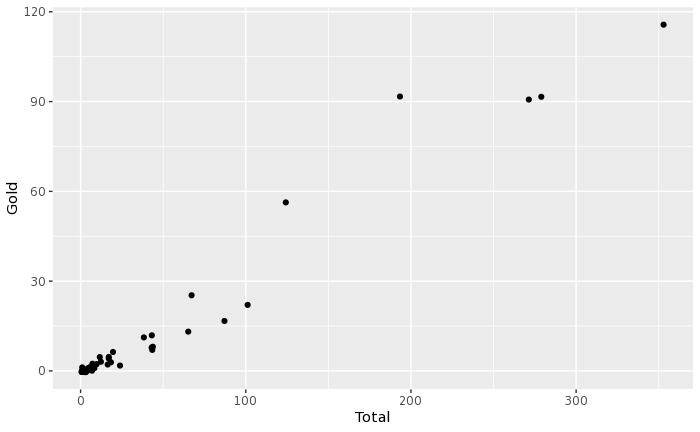

```r
ggplot(data = medalranks, aes(x = Total, y = Gold)) +
  geom_jitter()
```

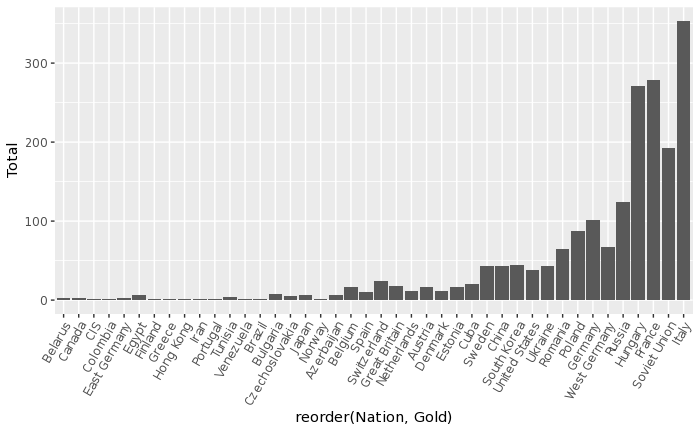

```r
ggplot(data=medalranks,aes(x=reorder(Nation,Gold),y=Total ))+geom_bar(stat='identity',position='stack', width=.9) + theme(axis.text.x=element_text(angle=60,hjust=1))
```

### (B) .Rmd Line number(s) for use of multiple aesthetics:

The below plot is the Olympics Medals count of each country, with a couple of aesthetics added, such as a reorder, a fill, and a theme of the x-axis. This data is relevant to the research question for same reason the above plots are. This data is interesting when comparing this plot to the bar plot above because it is weird how the three countries with the top total medal counts are the same on both plots.

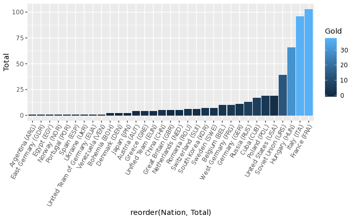

```r
OlympicMedals <- olympicslist[[12]] %>%
  filter(row_number() < 34)
ggplot(data=OlympicMedals,aes(x=reorder(Nation,Total),y=Total,order=reorder(Gold,Gold),fill=Gold))+geom_bar(stat='identity',position='stack', width=.9) + theme(axis.text.x=element_text(angle=60,hjust=1))
```

### (D) .Rmd Line number(s) for use of leaflet maps:

The plot below is a global choropleth map, showing the total number of medals each country has won. This data is interesting because most of the countries that have been dominant in the FIE Tournament are grouped together in the map. Russia does have a good amount of medals, and everywhere else along just looks like a void.

```
Mapping API still under development and may change in future releases.
4 items were not translated
```

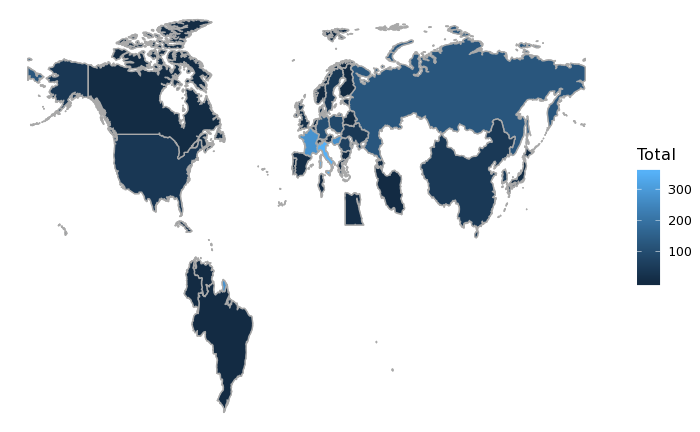

```r
WorldMap(medalranks, key = Nation, fill = Total)
```

## To Conclude:

Regarding all of the data, we have found that Italy has been the most dominant country in the FIE Tournament’s history, and France the most dominant country during the Olympics’ history.

To one of us, the results may be surprising, but to the other, who is a fencer, not at all. From experience, the United States does have a strong fencing environment, but some European countries do make our competition look like childs play.